# Distributional Consequences of Climate Policy

ESM 204 - Assignment 3

Alex Gaynor & Carlos Simms

# 1) Marginal Externality Cost of Gasoline

**The marginal externality cost per gallon of gasoline is `$`0.45 and found by $51 per metric ton/2204.62 lbs per metric ton * 19.6 lbs per gallon gas.**

# 2) Curves

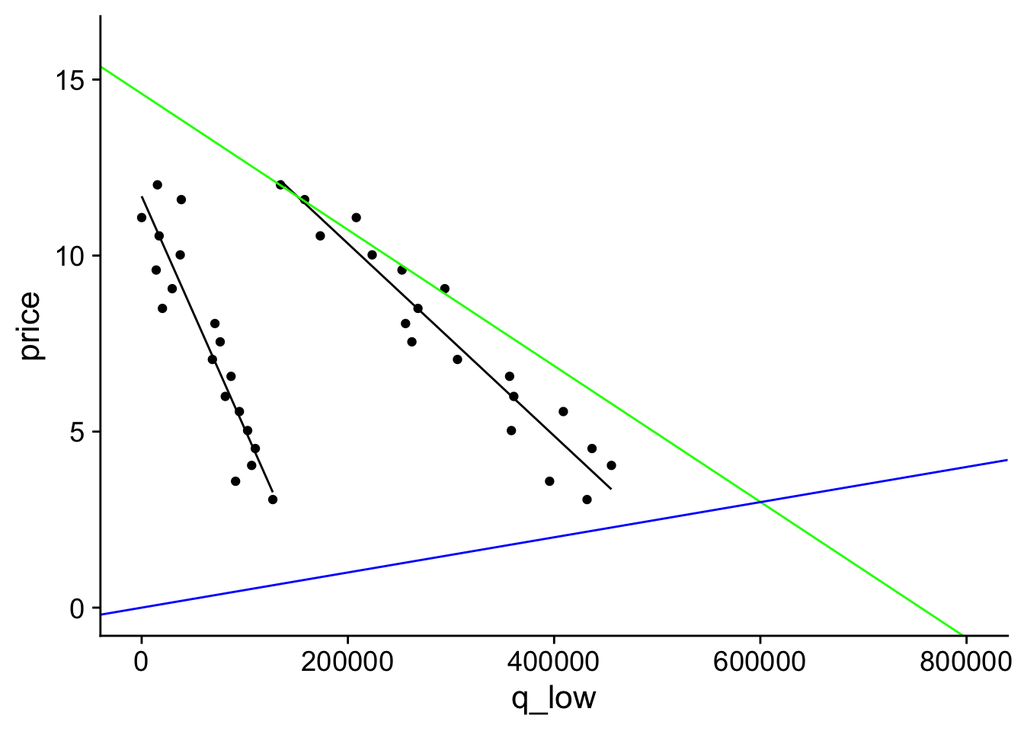

### What is the aggregate daily demand curve for gasoline?

**From $0 to 11.69: P = -0.0000193Q + 14.6, from 11.69 to infity: P = -0.0000273Q + 15.8**

### What is the supply curve for gasoline?

**P = 0.000005Q + 0**

### What is the “benefit” to consumers under the status quo?

**3571830.1**

### What is the “benefit” to producers under the status quo?

**900302.3**

### What is the environmental cost under the status quo?

**272138.3**

# 3) Consumer Benefit

### How is the current consumer benefit divided between “high” and “low” income consumers?

**“High” income consumers attain `$`3001322 of benefit and “low” income consumers attain `$`570509 of benefit for a total of `$`3571830. “High” income consumers receive 84 percent of the total benefit.**

# 4) Derive the Optimal Gas Tax: `$`0.45

### a) How will this tax affect the amount of gasoline produced and consumed?

**The amount of gasoline produced and consumed will move from 600202, down to 576917.**

### c) How will this tax affect the overall welfare of “high” income consumers?

**Welfare for “high” income consumers will go from 3001322 down to 2792512, or a loss of 208809.**

### d) How will this tax affect the overall welfare of “low” income consumers?

**Before the tax, total welfare for “low” income consumers 298370 was the total benefit 570509 for “low” income people - the environmental damage burden that fell on them 272138. After the tax, the new total benefit for “low” income people is 250997, or a gain of -47373.**

### e) How will this tax affect gas producers?

**Supplier surplus for producers will go from 900302 down to 831295, or a loss of 69007.**

### g) How will this tax affect total tax revenue generated?

**Instead of $0 in tax, this will generate 261501.**

# 5) Redistributing Gas Tax Revenue to Consumers

| SCC $/MTCO2eq. | Tax Rate $ | Pre Distribution High $ | Pre Distribution Low $ | Post Distribution High $ | Post Distribution Low $ | Producer Surplus $ |
| --- | --- | --- | --- | --- | --- | --- |
| 0 | 0.00 | 3001322 | 570508.5 | 3001322 | 570508.5 | 900302.3 |
| 51 | 0.45 | 2792512 | 250997.5 | 2996776 | 585773.2 | 831295.3 |
| 75 | 0.67 | 2696854 | 109076.8 | 2991492 | 591969.7 | 799773.4 |
| 100 | 0.89 | 2598982 | -33015.0 | 2983847 | 597752.9 | 767586.0 |
| 125 | 1.11 | 2502920 | -169247.5 | 2974017 | 602850.8 | 736059.6 |
| 150 | 1.33 | 2408666 | -299620.6 | 2962004 | 607263.4 | 705194.3 |

### a) Overall welfare of “high” income consumers:

**As SCC increases from $51 to $150, a pre-distribution gas tax would have a negative impact on “high” income consumers, decreasing their consumer benefit from $2792512 to $2408666. And via post-distribution, “high” income consumers will only be negatively impacted slightly, decreasing their consumer benefit from $2996776 to $2962004.**

### b) Overall welfare of “low” income consumers:

**As SCC increases from $51 to $150, a pre-distribution gas tax would have a significant negative impact on “low” income consumers, decreasing their consumer benefit from $250997 to -$299620. And post-redistribution, “low” income consumers will greatly benefit, increasing their consumer benefit from $585773 to $607263.**

### c) Overall welfare of gas producers:

**As SCC increases from $51 to $150, a gas tax would have a negative impact on gas producers. Producer surplus would decrease from $831295 to $705194.**

# 6) New Demand From New Electric Car Technology

### a) What is total gas consumption?

**310860**

### b) What is the total environmental externality?

**At a SCC of $51, the tax rate is $0.45, multiplied by the total gas consumption = 140947.**

### c) What value of the gasoline tax makes the total environmental damage the same as the electric car technology?

**“the same as the electric car technology” was taken to mean (environmental value per gallon saved: $0.45 if the SCC is $51)x(gallons used after some “high” income people switch to electric) = 140947. In order to generate the same amount via a tax on the remaining gallons of gas consumed, you would divide the amount by the miles still driven and get 0.45.**